# References, Publications, OA-Available over Time

UVA StatLab/RDS

### 4a. UVA References in Big 5 Provider Journals over Time

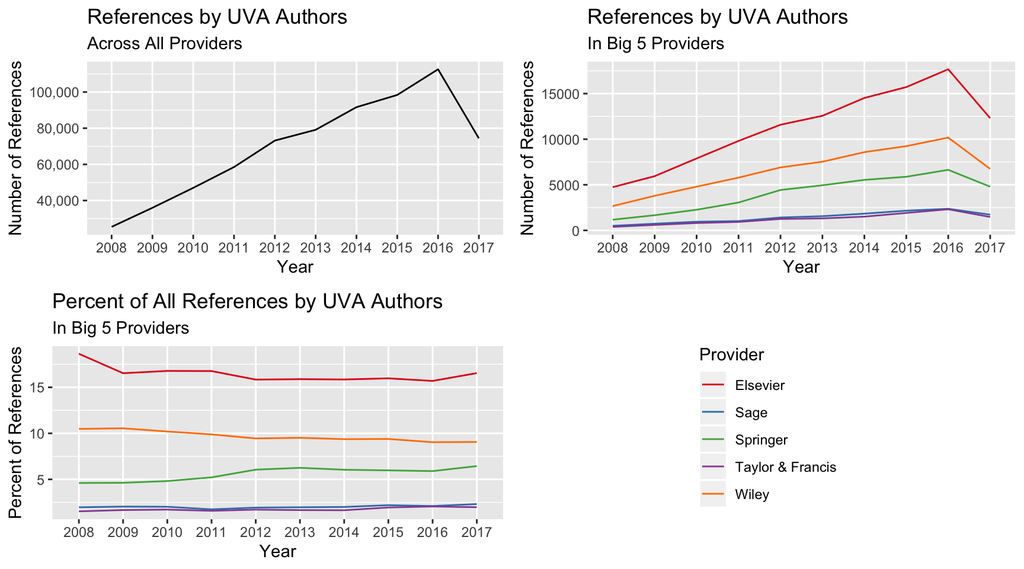

Figure 4 shows trends in citations to the Big 5 providers by UVA authors over time. The top panels reveal an overall growth in research output by UVA researchers, and therefore in citations. The lower panel, showing citations to each provider as a percentage of total citations by UVA authors, suggests that citations to Elsevier titles represent a relatively larger portion of citations relative to the others. This proportion has been flat (if not very slightly in decline) for most of the decade.

### 4b. UVA References in Big 5 Provider Journals over Time

The figure above is repeated below but with Elsevier journals disaggregated into the Freedom collection, Subscribed collection, and journals we were not able to match.

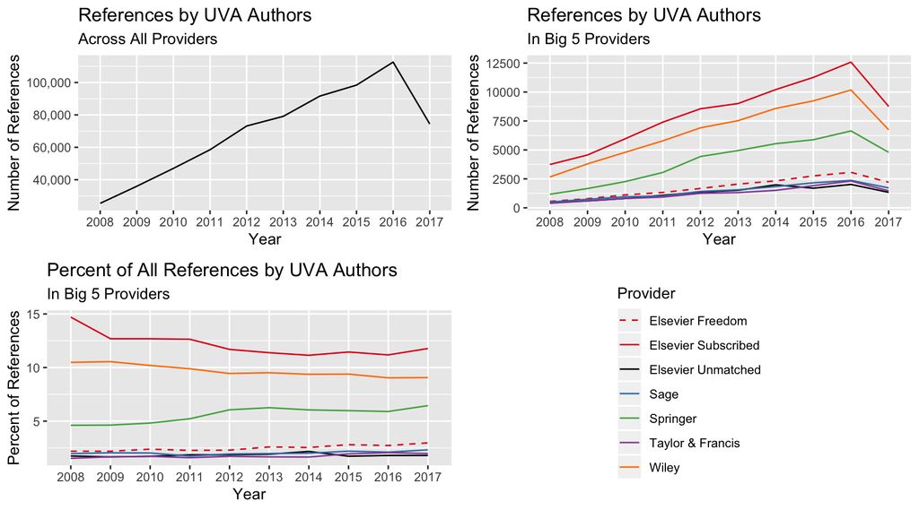

Focusing on the Elsevier Subscribed Collection, we see that citations to Elsevier Subscribe titles continue to represent a relatively larger proportion of citations, though the decline in the proportion across the decade is clearer.

### 5a. UVA Publications in Big 5 Provider Journals over Time

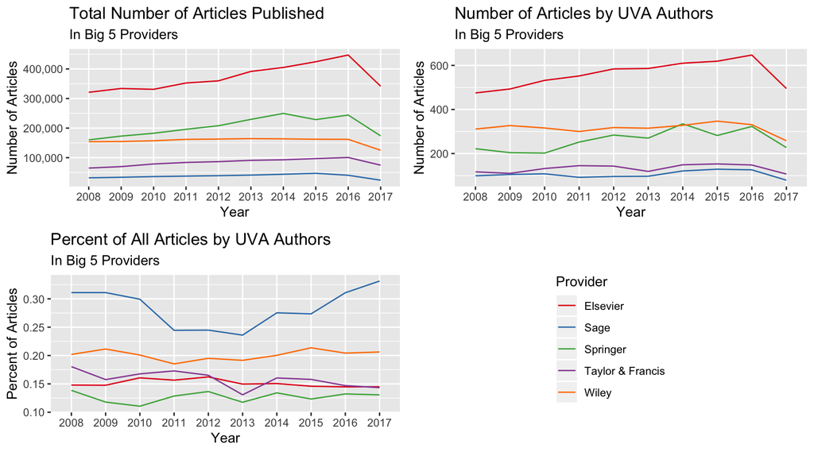

The top panel indicates that Elsevier and Springer have been publishing more articles over time; at the same time, UVA authors are publishing more articles in the journals provided by Elsevier and Springer. Consequently, the relative amount of UVA work published in Elsevier journals is stable over the last decade.

### 5b. UVA Publications in Big 5 Provider Journals over Time

The figure above is repeated below but with Elsevier journals disaggregated into the Freedom collection, Subscribed collection, and journals we were not able to match.

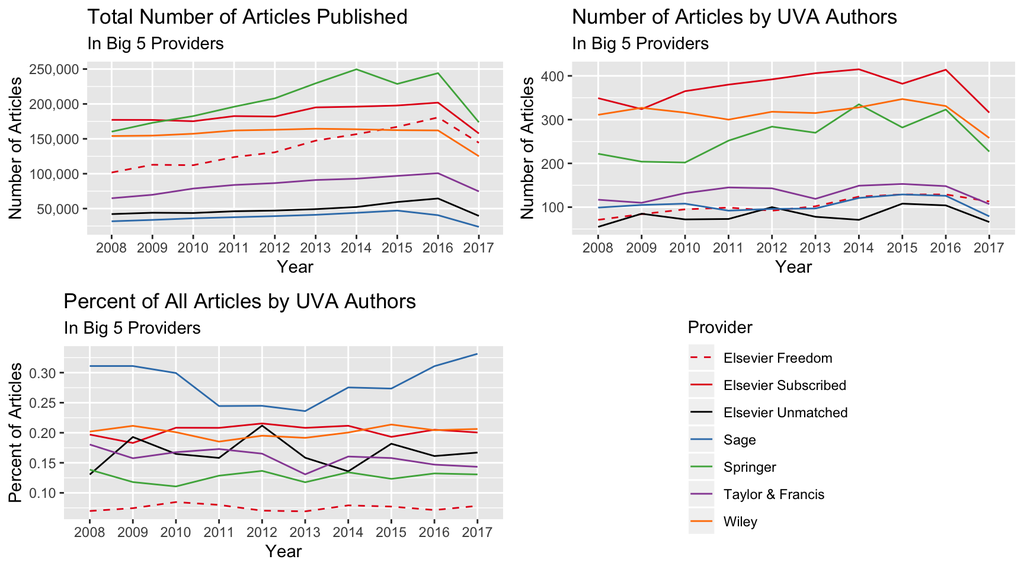

Much of the growth in articles published in Elsevier journals is occuring in journals within the Freedom Collection. Even so, the percent of articles by UVA authors in Elsevier’s collections remains stable.

### 6a. OA-Available Articles in Big 5 Provider Journals over Time

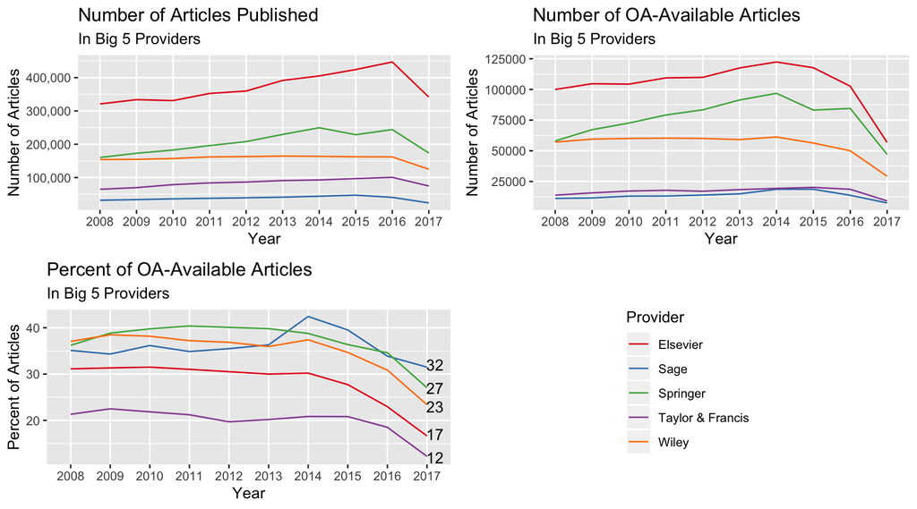

The top panel, again, indicates that Elsevier and Springer have been publishing more articles over time, and the number of OA-available articles in these providers’ titles has been increasing as well. The drop off in OA availability for more recent content likely reflects the rolling embargo window imposed by vendors. Piwowar et al. found in a study of national OA availability trends that OA availability is increasing in recent years, and that for the most recent year they studied, 2015, 45% of the articles were available in OA versions. However, it seems that this percentage varies strongly depending on the provider, with Elsevier and Taylor & Francis keeping more of their content behind paywalls.

### 6b. OA-Available Articles in Big 5 Provider Journals over Time

The figure above is repeated below but with Elsevier journals disaggregated into the Freedom collection, Subscribed collection, and journals we were not able to match.

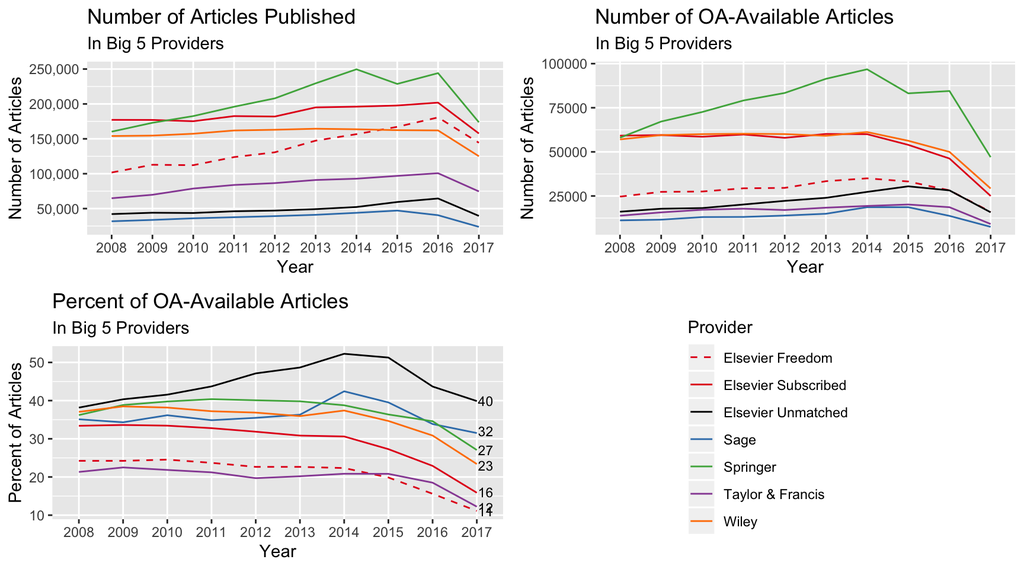